# إBalad data set

# —————————————————————————————–

# ——————————— ———————————–

# ——————————— Answering Questions ———————————–

# ——————————— ———————————–

# —————————————————————————————–

# does NetErro effect result?

# does Field Error Effect the result?

# what is in common between poeple who are are undone?

Here we label 3 types of usage. and we identify a rule to destinguish each : # # 1.Classic Wizzard # Definition: # users who are simply passing wizzard steps 1 by 1. # 1 -> 2 -> 3 # Characteristic: # They are usually end up successfully # rule: # page_cnt = 2 && page_sum = 0 == # page_sum = 6 ==> classic wizzard # # # 2.Back and Forth # Definition: # users who are not following the wizzard. they wondering between pages # Characteristic: # 1 -> 2 -> 3 ->2 ->1 : most likely to result in fialur and leaving the process # 1 -> 2 -> 3 ->2 ->3 : most likely to end up successfully # rule: # page_sum>= 8 ==> back and forth # # # 3. to zero # Definition: # This users might never visit page 3 # Characteristic: # They mostly result in fialur and leaving the process # page_sum <=1 == # page_cnt = 3 && page_sum = 3 == > to zero # #  
* usage_pattern: 1:to zero1 2:Classic Wizzard 3:Back and Forth # #################################################################################### # From This results find out that # 1. those who come back to 0, leave the process undone # 2. Those who back and forth and stop by Page#3 finish successfully # 3. Those who back and forth and stop by Page#0 leave undone # 4. those who follow thi wizzard are more likely to finish the successfully # # ####################################################################################

```r
library(dplyr)
res1<- df.loops %>%
  filter(v1=='New 1') %>%
  group_by(result,substr(v2,1,9),substr(v3,1,9),substr(v4,1,9),substr(v5,1,9),substr(v6,1,9),substr(v7,1,9),substr(v8,1,9),substr(v9,1,9),page_cnt,page_sum ) %>%
  summarise(
    cnt = n()
  )  %>%
  arrange(desc(cnt))
nrow(res1)  #1153
res1[1:20,]
```

```r
ncol(df.loops)
```

```
[1] 227
```

Q: How does page_cnt effect the result? * page count is 1 unit less that reallity bczof programming style. that means wee need to add 1 to this measure. page_cnt = 0 means one page is seen.

| result | page_cnt | cnt |
| --- | --- | --- |
| 0 | 0 | 10641 |
| 1 | 0 | 131 |
| 0 | 1 | 76849 |
| 1 | 1 | 138 |
| 0 | 2 | 759 |
| 1 | 2 | 54437 |
| 0 | 3 | 2607 |
| 1 | 3 | 2347 |
| 0 | 4 | 121 |
| 1 | 4 | 6527 |

[output cut: 30 more lines]

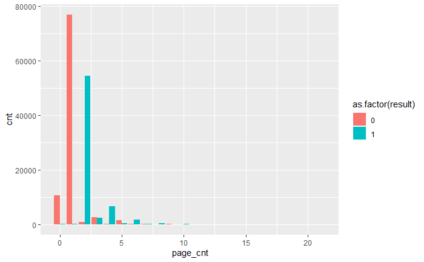

| result | page_sum | page_cnt | cnt |
| --- | --- | --- | --- |
| 0 | 0 | 1 | 76849 |
| 1 | 0 | 2 | 54437 |
| 0 | 0 | 0 | 10641 |
| 1 | 0 | 4 | 6527 |
| 0 | 0 | 3 | 2607 |
| 1 | 0 | 3 | 2347 |
| 1 | 0 | 6 | 1687 |
| 0 | 0 | 5 | 1521 |
| 0 | 0 | 2 | 759 |
| 1 | 0 | 5 | 434 |

[output cut: 30 more lines]

—————————————- Network Error Assessment————————————————-

Q :Does Net Error impact the resutl? A : Total number is different. but is there significantly different?

| page_sum | net_er_level | cnt |
| --- | --- | --- |
| 0 | 0 | 77268 |
| 5 | 1 | 43694 |
| 5 | 0 | 11052 |
| 0 | 1 | 10657 |
| 8 | 1 | 4554 |
| 6 | 0 | 2005 |
| 8 | 0 | 1473 |
| 6 | 1 | 1287 |
| 3 | 0 | 1108 |
| 1 | 0 | 1064 |

[output cut: 56 more lines]

desc: We need to assess that with chi-square. But se should transform it first, since chi-square works with Normal Distibution A: p-value = 1 shows that there is not significance interaction between “Net_err_cnt” and “result”

```r
chisq.test( t   )
```

```
Chi-squared approximation may be incorrect
```

```
    Pearson's Chi-squared test

data:  t
X-squared = 27.048, df = 68, p-value = 1
```

Q: Does network Error Effect visited pages?

| page_sum | net_er_level | cnt |
| --- | --- | --- |
| 0 | 0 | 87618 |
| 0 | 1 | 315 |
| 1 | 0 | 1206 |
| 1 | 1 | 10 |
| 2 | 0 | 152 |
| 2 | 1 | 28 |
| 3 | 0 | 1824 |
| 3 | 1 | 85 |
| 4 | 0 | 151 |
| 4 | 1 | 10 |

[output cut: 54 more lines]

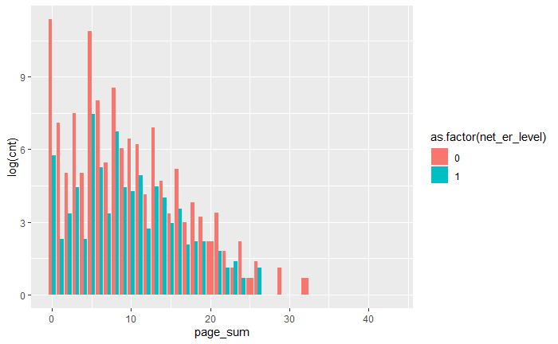

desc: We need to assess that with chi-square. But se should transform it first, since chi-square works with Normal Distibution A: p-value = 1 shows that there is not significance interaction between “Net_err_cnt” and “page_sum”

```r
chisq.test( t   )
```

```
Chi-squared approximation may be incorrect
```

```
    Pearson's Chi-squared test

data:  t
X-squared = 13.387, df = 42, p-value = 1
```

[output not shown]

A: Errors does not preventusers from going through the process. users visiting more pages, experiencing even more Net Error.

- lets Just remember that majority of people are stoping at page 1

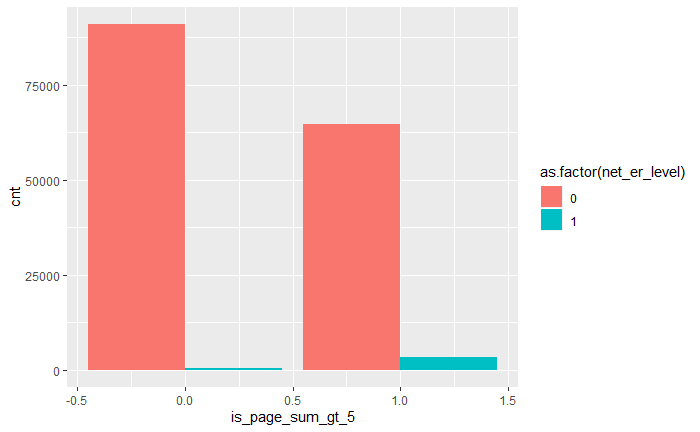

| result | net_er_level | cnt |
| --- | --- | --- |
| 0 | 0 | 80334 |
| 1 | 0 | 15039 |
| 0 | 1 | 12713 |
| 1 | 1 | 51262 |

# Now the Question is:

# why people do not go furthur from page 1 or 2?

# does Network Err or field Error play any role?

```r
summary(df.loops$Net_err_cnt)
is_page_sum_lt_3

res1<- df.loops %>%
  filter(v1=='New 1' & result<=1 & Net_err_cnt<10 ) %>%
  # group_by(result,  is_page_sum_lt_3 =  ifelse(page_sum>=5,1,0)  , net_er_level = round(Net_err_cnt/3,0)) %>%
  group_by(result,  is_page_sum_lt_3 =  ifelse(page_sum>=5,1,0)  , net_er_level = ifelse(Net_err_cnt>=1,1,0)) %>%

  summarise(
    cnt = n()
  )  %>%
  arrange(net_er_level,is_page_sum_lt_3)
nrow(res1)  #63
res1[1:20,]
####  Majority of failaur cases stop at page 0 for no reason. It s a routine  case in marketing data. this people are just trying options of the page.
####  lets ignor this group
#
#
# result is_page_sum_lt_3 net_er_level   cnt
# 1      0                0            0 79505
# 2      1                0            0   169
# 3      0                1            0   829
# 4      1                1            0 14870
# 5      0                0            1 11571   *
# 6      1                0            1   145   *
# 7      0                1            1  1142   *
# 8      1                1            1 51117   *
ggplot(data = res1 ,aes( x=Net_err_cnt , y = cnt,fill = as.factor(result) ))+
  geom_bar(stat = "identity",position = position_dodge())+
  geom_text( aes( label = Net_err_cnt))
```

———————————- fixing the rule of “patterns” ————————————–

```r
nrow(res1)  #63
```

```
[1] 189
```

getting to know this three groups statistically:

is_classic_wizzard_user 57497 / (57497+199) = 99.6 % sucessfull is_back_Forth_user_user 7960 / (1701 +7960 ) = 82.3 % sucessfull ==> when page_cnt = 4 then success - when page_cnt=5 then fialur is_to_zero 90724 / (90724+171) = 99.8 % failur

when he reachs page 2 and 3: 1 -> 2 -> 3 -> it will be so probable to success (57497 + 7960+ 1701) /( 674 + 432 +7960+ 1701 + 57497 + 199) = 98% chance to get succusfull

if he comes back to 2: 1 -> 2 -> 3 -> 2 …>1 there is 1701 / (1701+7960)= 17% chance that he chooses 1 in next step and the process finishes undon

if he comes back to 2: 1 -> 2 -> 3 -> 2 …>3 there is 7960 / (1701+7960)= 82% chance that he chooses 3 in next finishs the process succesfully

| result | is_classic_wizzard_user | is_back_Forth_user_user | is_to_zero | cnt |
| --- | --- | --- | --- | --- |
| 0 | 0 | 0 | 0 | 432 |
| 1 | 0 | 0 | 0 | 674 |
| 0 | 0 | 0 | 1 | 90724 |
| 1 | 0 | 0 | 1 | 171 |
| 0 | 0 | 1 | 0 | 1701 |
| 1 | 0 | 1 | 0 | 7960 |
| 0 | 1 | 0 | 0 | 199 |
| 1 | 1 | 0 | 0 | 57497 |

—————————————- Field Error Assessment————————————————-

# Here I am testing all error counts, against the “result” to see which type

# in case FE_brand happens but page >=5 then susscess full.

# below error types are looking more effective amoung others:

# row result is_page_sum_gt_3 FE_? cnt

# FE_location:

# 5 1 1 1 4383

# 6 0 0 1 133

# 7 0 1 1 105

# 8 1 0 1 4

# 4383

# FE_category:——————————

# 5 1 1 1 1861

# 6 0 0 1 84

# 7 0 1 1 68

# FE_description:—————————

# 5 1 1 1 992

# 6 0 0 1 892

# 7 0 1 1 68

# 8 1 0 1 4

# 9 1 1 2 142

# 10 0 0 2 140

# 11 0 1 2 25

# 12 0 0 3 73

# 13 1 1 3 56

# 14 0 1 3 5

# FE_title———————————–

# 5 1 1 1 940

# 6 0 0 1 827

# 7 0 1 1 53

# 8 1 0 1 2

# 9 1 1 2 185

# 10 0 0 2 112

# 11 0 1 2 15

# 12 1 1 3 94

# 13 0 0 3 75

# 14 0 1 3 8

# 15 1 1 4 49

# 16 0 0 4 44

# 17 0 1 4 3

# Result:

# Below fields can effect user, and stop him by page 1 or 2

# FE_title

| result | is_page_sum_gt_3 | FE_category | cnt |
| --- | --- | --- | --- |
| 0 | 0 | 0 | 90957 |
| 1 | 1 | 0 | 63823 |
| 0 | 1 | 0 | 1861 |
| 1 | 0 | 0 | 313 |
| 1 | 1 | 1 | 1861 |
| 0 | 0 | 1 | 84 |
| 0 | 1 | 1 | 68 |
| 1 | 0 | 1 | 1 |
| 1 | 1 | 2 | 172 |
| 0 | 1 | 2 | 15 |

[output cut: 10 more lines]

Q : is there any relationship between Network Error and usage_pattern? A: As previously showed, Network Error emerged so high in rate, for users who visited more pages. for sure it can not be an abstacle

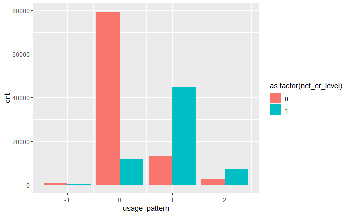

Q : is there any relationship between Field Error and usage_pattern? A : It does not significantly show any causuality relationship. in segment#2 (Classical_wizzard_users), which are 99% successful, we can see most field Errors. They can not be taken as any obstacle.

```r
 df.loops %>%
  filter(v1=='New 1' & result<=1  ) %>%
  group_by(usage_pattern, has_field_err = ifelse(field_err_cnt>=1,1,0)   ) %>%
  summarise(
    cnt = n()
  )  %>%
  arrange( desc(cnt)) %>%
  ggplot(aes( x=usage_pattern , y = cnt,fill = as.factor(has_field_err) ))+
   geom_bar(stat = "identity",position = position_dodge())
```

[output not shown]

# lets test logetic regression to find out which factors play a role in finishing the job successfully

# 1. how does factors effect result?

# 2. how does factors obstacle user in page 0?

# 3. how does factors obstacle user in 1-2-3-2 to comebacke to page 1?

# how does factors effect result?

```r
df.loops.gl$page_cnt    <-    factor( ifelse(  df.loops.gl$page_cnt<=5 , df.loops.gl$page_cnt,10) )
```

[output not shown]

important result

Q. How does field Errors effect user to be “is_to_zero” segment?

A. by testing filed and its intraction on page_cnt, we highlight that, below filed, negatively effect user, put him/her in “to_zero” serment, and stops him/her from going furthur in the wizzard

# page_cnt2:FE_description1 8.041e+00 5.985e-01 13.435 < 2e-16 *# page_cnt2:FE_title1 8.706e+00 7.209e-01 12.076 < 2e-16*

```r
summary(mdl_result1_factor)
```

[output not shown]

[output cut: 93 more lines]

```
page_cnt2:FE_type1          -1.556e+01  1.043e+03  -0.015 0.988094
page_cnt3:FE_type1          -4.504e+00  1.006e+00  -4.479 7.49e-06 ***
page_cnt4:FE_type1          -1.327e+01  2.243e+03  -0.006 0.995281
page_cnt5:FE_type1          -7.197e-01  3.862e+03   0.000 0.999851
page_cnt10:FE_type1         -1.328e+00  3.406e+03   0.000 0.999689
---
Signif. codes:  0 ‘***’ 0.001 ‘**’ 0.01 ‘*’ 0.05 ‘.’ 0.1 ‘ ’ 1

(Dispersion parameter for binomial family taken to be 1)

    Null deviance: 342201  on 246945  degrees of freedom
Residual deviance:  17884  on 246849  degrees of freedom
AIC: 18078

Number of Fisher Scoring iterations: 19
```

```r
mdl_result1_factor <- glm(result ~ FE_brand:page_cnt +FE_brand_model:page_cnt + FE_category:page_cnt
                          + FE_category:page_cnt +   FE_description:page_cnt +FE_link:page_cnt +       FE_location:page_cnt+  FE_national_id:page_cnt + FE_new_credit:page_cnt  +  FE_new_price:page_cnt +   FE_phone:page_cnt
                          + FE_post_type:page_cnt + FE_rooms:page_cnt
                          +       FE_simcard_type:page_cnt  + FE_size:page_cnt  +        FE_title:page_cnt
                          +       FE_type:page_cnt
                          + FE_usage
                          +       FE_user_type +   FE_year
                          , data = df.loops.gl, family = "binomial")
```

```
glm.fit: algorithm did not convergeglm.fit: fitted probabilities numerically 0 or 1 occurred
```

Conclusion

There are 3 patterns which users follow.

is_classic_wizzard_user 57497 / (57497+199) = 99.6 % sucessfull is_back_Forth_user_user 7960 / (1701 +7960 ) = 82.3 % sucessfull ==> when page_cnt = 4 then success - when page_cnt=5 then fialur is_to_zero 90724 / (90724+171) = 99.8 % failur

is_classic_wizzard_user reaches page 2 and 3 is_back_Forth_user_user reaches 2 and 3 and wonders around. If he gets backe to page 1, there is a high chance that he/she might fails but if she/he gets backe to page 3, most probably she/he will successfully finish the chain. is_to_zero never reaches page 3 and sometimes even page 2 ( this is the most common case)

so: 1. what makes people stock on first pages and do no proceed to next page? sometimes they are just trying “Add advertise” butt or sometimes, based on logestic regression, there are some fileds, that significiantly, increase the chance of being in “is_to_zero” segment. Description + title errors on this field increase the chance of being in “is_to_zero” segment, therefor decrease the chance of visiting other pages, that is capstone of ending unsuccessfully. on the other hand, there are some fileds on age 3, which attract usere to click on finish and submite the advertisment. we need to make user visit that page faster. As I tried this dunction on Divar App, I found out page 3, includes lots of “Selection Components”. They are easy to fill, and attractive for user. But Title and Descrption textboxs, are hard to fill. It’s hard for android user to fill it. I guess users give up, when they see this 2 big textboxes and they miss fantastic multi-selection components of page3.

suggestion: what if you put Description and Title Textboxs on page 3, and show users attractive multi-selection components first? they are easy to fill out, and when user reach Desciption and Title and very last page, he/she would more likely fill the boxs, cause that’s the last step.He wont give up whole process now, while he has already filled a lot. that would be a wast to quite at page 3.

2.What makes people reach page 3, come backe to page 2, but never get back to the wizzard fot page 3 agian? I did not have enough time to answer this question but there are 20% of “is_back_Forth_user_user” segment, that we lose on this regard.